# Lab 5: Statistics

Normal Distribution, Histograms, R Functions

Normal Distribution

Cumulative Distribution Function

Probability Density Function

Author

Bogdan G. Popescu

# 1 Intro

Open a new Quarto document. Select all text by pressing Ctrl + A (Windows) or Cmd + A (Mac), then press Delete. Next, copy and paste the following preamble.

```yaml
---
title: "Lab 5"
author: "Your Name"
date: "September 13, 2024"
format:
  html:
    toc: true
    number-sections: true
    colorlinks: true
    smooth-scroll: true
    embed-resources: true
---
```

Render the document and save it under “week5” in your “stats” folder.

# 2 Background

```r
#Removing previous datasets in memory
rm(list = ls())
#Loading the relevant libraries
#install.packages("gghighlight")
library(ggplot2)
library(gridExtra)
library(gghighlight)
```

Before we get into coding, let us go back to a short explanation of how frequencies relate to probability mass functions (pmf) and cumulative distribution functions (cdf).

[video not shown]

There are four functions in R related to distributions: `rnorm`, `pnorm`, `qnorm`, `dnorm`.

# 3 Generating Random heights in a Normal Distribution

The `rnorm` function generates a vector of normally distributed random numbers. We can specify the mean $\mu$ and the standard deviation $\sigma$. Let’s simulate women’s heights in centimeters and demonstrate how heights follow a normal distribution.

Let us see how it works by creating three samples with 20, 100, and 1000 observations to demonstrate the impact of sample size on the normal distribution.

## 3.1 Creating a sample of 20 observations: heights

```r
#Set seed allows us to make sure everyone gets the same results
set.seed(123)
#Step1: Creating 20 obs. with mean 165 and sd of 10
generated_heights_20obs<-rnorm(20, mean = 165, sd = 10)
#Step2: Turning the created data into a data frame
generated_heights_20obs<-data.frame(generated_heights_20obs)
#Step3: Inspecting the first 10 obs.
head(generated_heights_20obs, n=10)
```

|  | generated_heights_20obs |
| --- | --- |
| 1 | 159.3952 |
| 2 | 162.6982 |
| 3 | 180.5871 |
| 4 | 165.7051 |
| 5 | 166.2929 |
| 6 | 182.1506 |
| 7 | 169.6092 |
| 8 | 152.3494 |
| 9 | 158.1315 |
| 10 | 160.5434 |

```r
#Step4: Renaming variable inside the datafarme
names(generated_heights_20obs)<-"height"
```

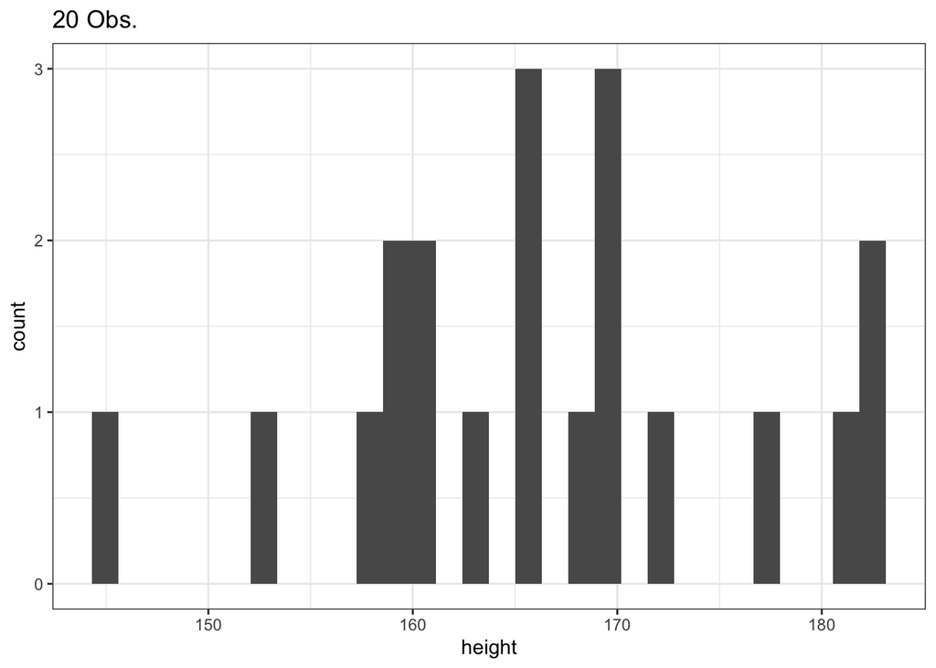

```r
#Step5: Plotting the data
figure_1<-ggplot(data = generated_heights_20obs, aes(x=height))+
  geom_histogram()+
  theme_bw()+
  ggtitle("20 Obs.")
figure_1
```

## 3.2 Creating a sample of 100 observations: heights

```r
set.seed(123)
#Step1: Creating 100 obs. with mean 165 and sd of 10
generated_heights_100obs<-rnorm(100, mean=165, sd=10)
#Step2: Turning the created data into a data frame
generated_heights_100obs<-data.frame(generated_heights_100obs)
#Step3: Inspecting the first 10 obs.
head(generated_heights_100obs, n=10)
```

|  | generated_heights_100obs |
| --- | --- |
| 1 | 159.3952 |
| 2 | 162.6982 |
| 3 | 180.5871 |
| 4 | 165.7051 |
| 5 | 166.2929 |
| 6 | 182.1506 |
| 7 | 169.6092 |
| 8 | 152.3494 |
| 9 | 158.1315 |
| 10 | 160.5434 |

```r
#Step4: Renaming variable inside the datafarme
names(generated_heights_100obs)<-"height"
```

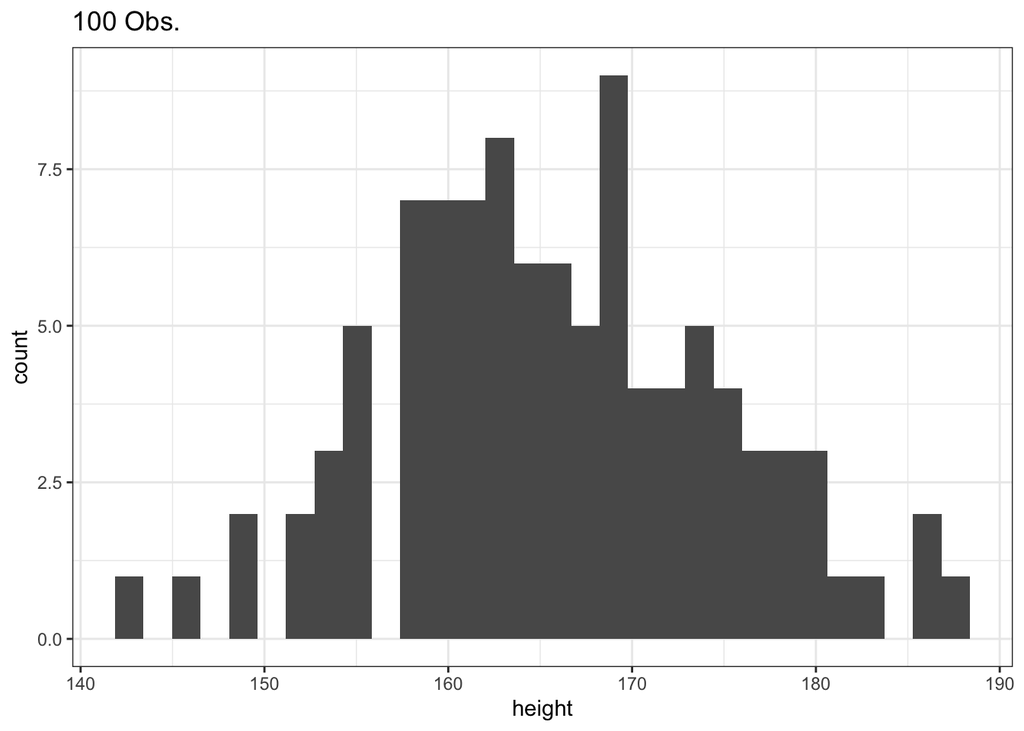

```r
#Step5: Plotting the data
figure_2<-ggplot(data = generated_heights_100obs, aes(x=height))+
  geom_histogram()+
  theme_bw()+
  ggtitle("100 Obs.")
figure_2
```

## 3.3 Creating a sample of 1000 observations: heights

```r
set.seed(123)
#Step1: Creating 1000 obs. with mean 165 and sd of 10
generated_heights_1000obs<-rnorm(1000, mean=165, sd=10)
#Step2: Turning the created data into a data frame
generated_heights_1000obs<-data.frame(generated_heights_1000obs)
#Step3: Inspecting the first 10 obs.
head(generated_heights_1000obs, n=10)
```

|  | generated_heights_1000obs |
| --- | --- |
| 1 | 159.3952 |
| 2 | 162.6982 |
| 3 | 180.5871 |
| 4 | 165.7051 |
| 5 | 166.2929 |
| 6 | 182.1506 |
| 7 | 169.6092 |
| 8 | 152.3494 |
| 9 | 158.1315 |
| 10 | 160.5434 |

```r
#Step4: Renaming variable inside the datafarme
names(generated_heights_1000obs)<-"height"
```

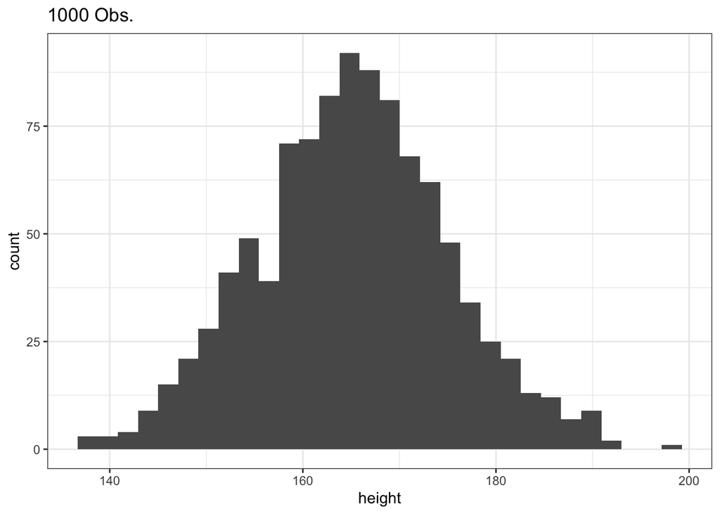

```r
#Step5: Plotting the data
figure_3<-ggplot(data = generated_heights_1000obs, aes(x=height))+
  geom_histogram()+
  theme_bw()+
  ggtitle("1000 Obs.")
figure_3
```

## 3.4 Comparing the distribution of the three different samples

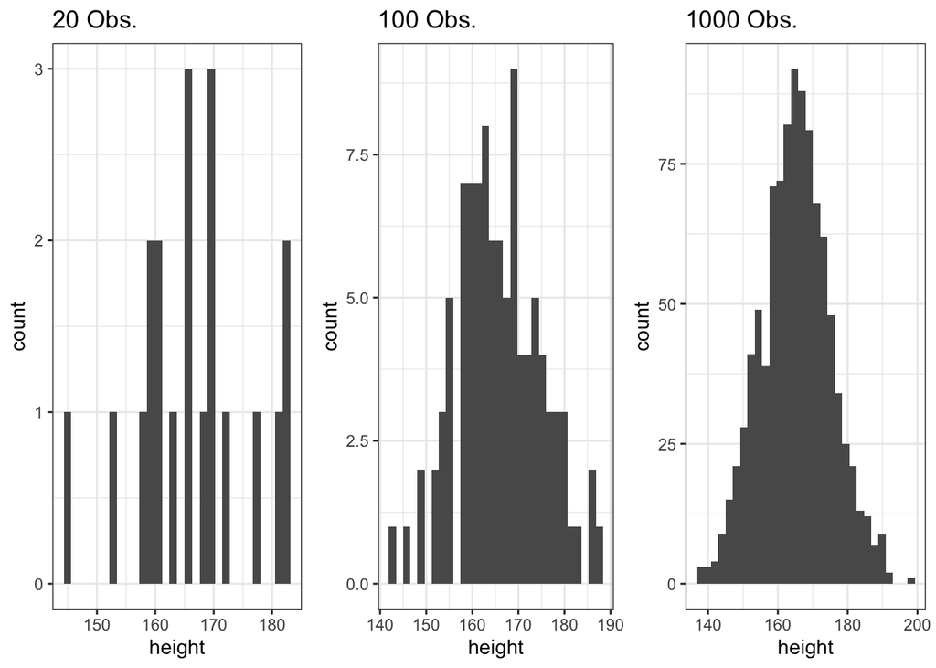

```r
new_fig<-grid.arrange(figure_1, figure_2, figure_3, ncol=3)
```

- When Small samples (n = 20) → More variability, less smooth
- Large samples (n = 1000) → Converging to the theoretical normal distribution
- **Law of Large Numbers**: As n increases, the sample distribution approximates the population distribution.

# 4 Generating the cumulative distribution function (CDF) for a normal distribution of heights

The `pnorm` function generates a vector for a cumulative distribution function of the normal distribution. We can specify the mean $\mu$ and the standard deviation $\sigma$. The `pnorm` will return the probability that the randomly generated variable X takes on a a value less than or equal to x:

$F_X(x) = P (X\leq x)$

## 4.1 Heights of Women from 135 to 195cm

```r
# 99% of a normal distribution falls between mean - 3*sd and mean + 3*sd
list_heights <- seq(135, 195, by = 0.1)  # Heights from 135 to 195 cm
list_heights_df<-data.frame(list_heights)
```

```r
dummy_df<-pnorm(list_heights, mean = 165, sd = 10)
dummy_df<-data.frame(dummy_df)
```

```r
names(dummy_df)<-"probability"
dummy_df2<-cbind(dummy_df, list_heights)
names(dummy_df2)[names(dummy_df2)=="list_heights"]<-"heights"
```

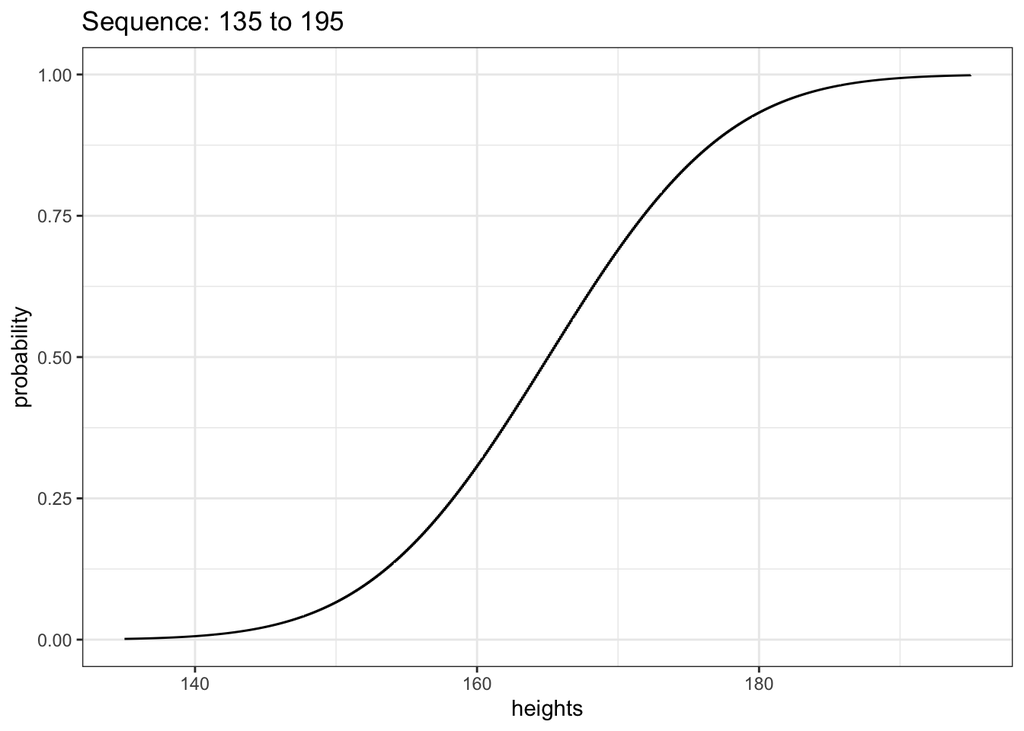

```r
figure_4<-ggplot()+
  geom_step(data=dummy_df2, mapping=aes(x=heights, y=probability)) +
  geom_bar(stat="identity")+
  theme_bw()+
  ggtitle("Sequence: 135 to 195")
figure_4
```

## 4.2 Highlighting probabilities

This will return the probability that the randomly generated variable X takes on a height less than or equal to 150cm.

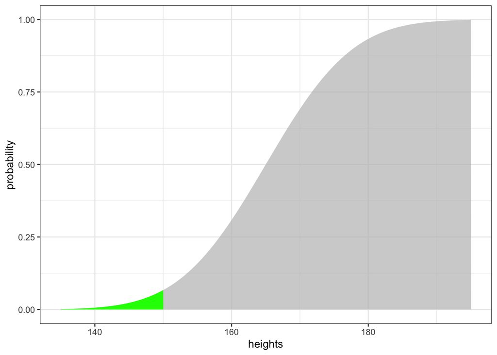

```r
figure_5<-ggplot(data=dummy_df2, aes(x=heights, y=probability)) +
      geom_area(fill = "green") +
      gghighlight(list_heights <= 150)+
      theme_bw()
figure_5
```

This will return the probability that the randomly generated variable X takes on a height less than or equal to 170cm.

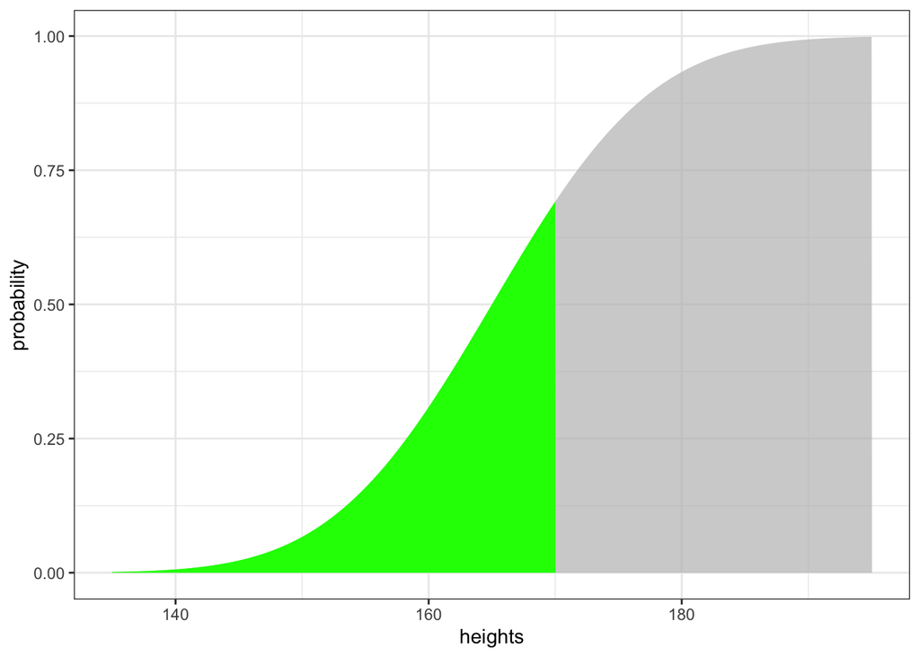

```r
figure_6<-ggplot(data=dummy_df2, aes(x=heights, y=probability)) +
       geom_area(fill = "green") +
       gghighlight(list_heights <= 170)+
       theme_bw()
figure_6
```

## 4.3 Changing size of the randomly generated variable - heights of women: increments of 0.1

```r
list_heights <- seq(135, 195, by = 0.1)
```

```r
dummy_df<-pnorm(list_heights, mean = 165, sd = 10)
dummy_df<-data.frame(dummy_df)
names(dummy_df)<-"probability"
dummy_df2<-cbind(dummy_df, list_heights)
names(dummy_df2)[names(dummy_df2)=="list_heights"]<-"heights"
```

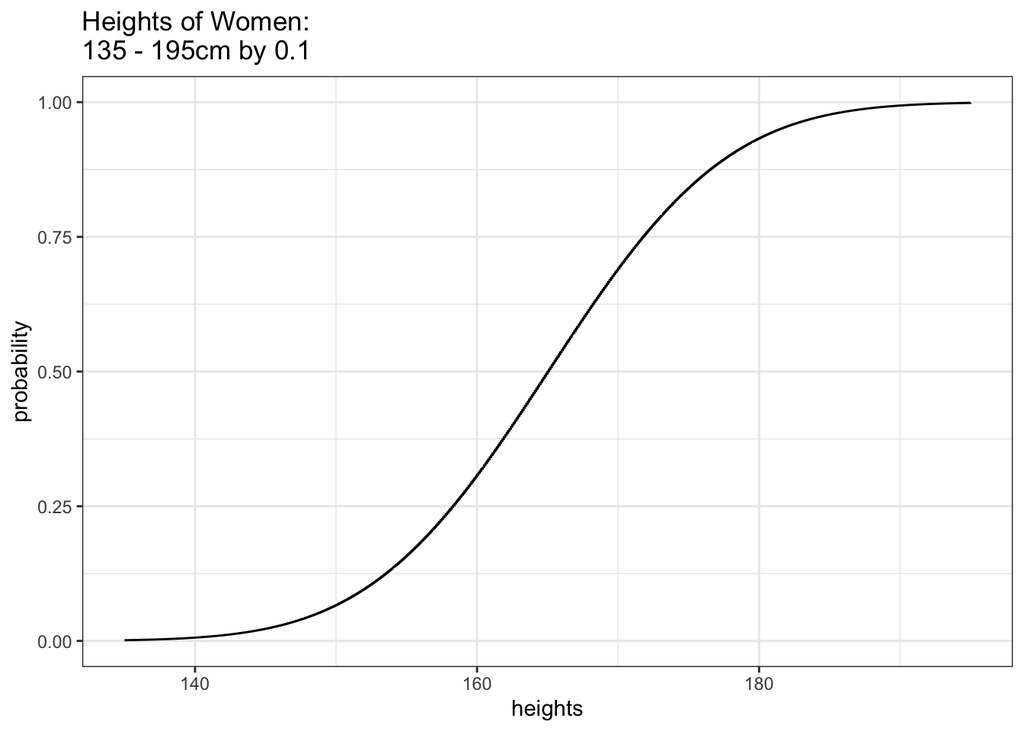

```r
figure_7<-ggplot()+
  geom_step(data=dummy_df2, mapping=aes(x=heights, y=probability)) +
  theme_bw()+
  ggtitle("Heights of Women:\n135 - 195cm by 0.1")
figure_7
```

## 4.4 Changing size of the randomly generated variable - heights of women: increments of 1

```r
list_heights <- seq(135, 195, by = 1)
dummy_df<-pnorm(list_heights, mean = 165, sd = 10)
dummy_df<-data.frame(dummy_df)
names(dummy_df)<-"probability"
dummy_df2<-cbind(dummy_df, list_heights)
names(dummy_df2)[names(dummy_df2)=="list_heights"]<-"heights"
```

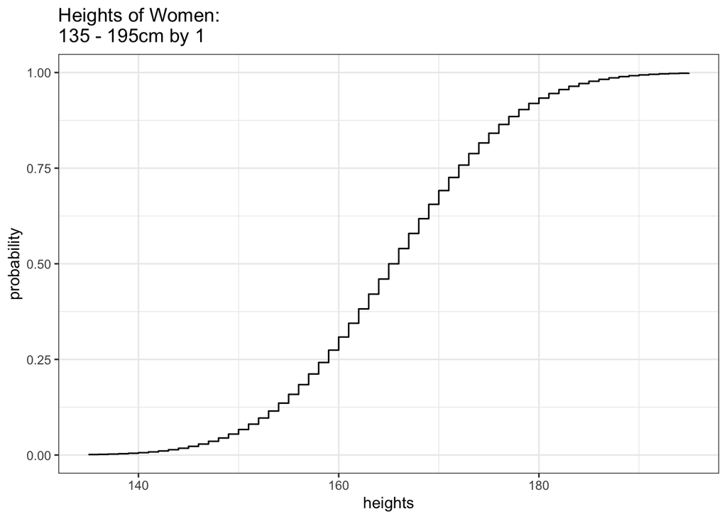

```r
figure_8<-ggplot()+
  geom_step(data=dummy_df2, mapping=aes(x=heights, y=probability)) +
  theme_bw()+
  ggtitle("Heights of Women:\n135 - 195cm by 1")
figure_8
```

## 4.5 Changing size of the randomly generated variable - heights of women: increments of 10

```r
list_heights <- seq(135, 195, by = 10)
dummy_df<-pnorm(list_heights, mean = 165, sd = 10)
dummy_df<-data.frame(dummy_df)
names(dummy_df)<-"probability"
dummy_df2<-cbind(dummy_df, list_heights)
names(dummy_df2)[names(dummy_df2)=="list_heights"]<-"heights"
```

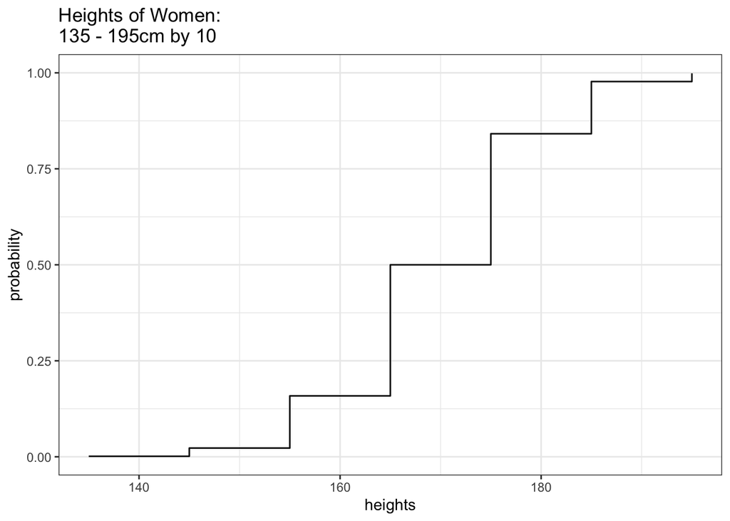

```r
figure_9<-ggplot()+
  geom_step(data=dummy_df2, mapping=aes(x=heights, y=probability)) +
  theme_bw()+
  ggtitle("Heights of Women:\n135 - 195cm by 10")
figure_9
```

## 4.6 Visualizing the results

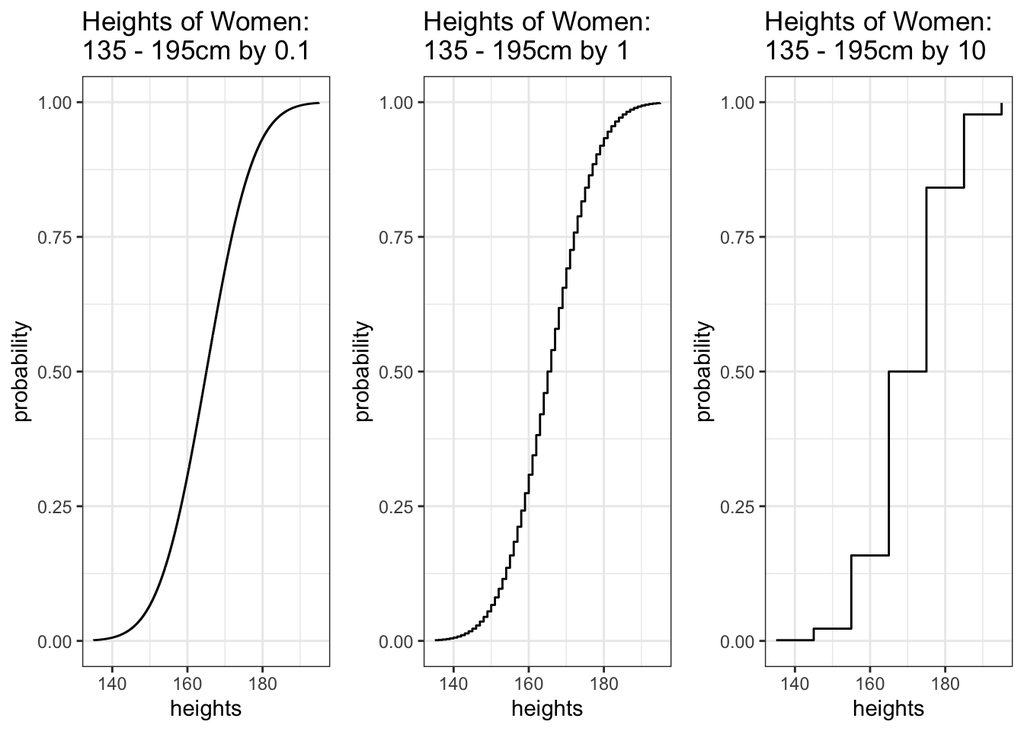

```r
grid.arrange(figure_7, figure_8, figure_9, ncol=3)
```

Smaller increments generate more data points for the CDF. This creates a smoother, more continuous-looking CDF. With by = 10, the CDF is “jumpy” because there are fewer points.

# 5 Generating the inverse of cumulative distribution function (CDF) for a normal distribution of heights

The `qnorm` function generates a vector for the inverse cumulative distribution function of the normal distribution with a mean $\mu$ and a standard deviation $\sigma$. It returns the height x such that `pnorm`(x, $\mu$, $\sigma$) = p

$P(X\leq x) = F_X(x)$

Let’s use the same data. First let us examine what we created previously.

```r
head(dummy_df2, n = 10)
```

|  | probability | heights |
| --- | --- | --- |
| 1 | 0.001349898 | 135 |
| 2 | 0.022750132 | 145 |
| 3 | 0.158655254 | 155 |
| 4 | 0.500000000 | 165 |
| 5 | 0.841344746 | 175 |
| 6 | 0.977249868 | 185 |
| 7 | 0.998650102 | 195 |

Because `qnorm` works in the opposite direction, we will use the probabilities (that the randomly generated variable X takes on a value less than or equal to x) to recreate the heights in our sequence

```r
probability2<-dummy_df2$probability
dummy_df_q<-qnorm(probability2, mean = 165, sd = 10)
dummy_df_q<-data.frame(dummy_df_q)
names(dummy_df_q)<-"q"
dummy_df_q2<-cbind(dummy_df_q, probability2)
```

Let us now inspect the output

```r
head(dummy_df_q2, n=10)
```

|  | q | probability2 |
| --- | --- | --- |
| 1 | 135 | 0.001349898 |
| 2 | 145 | 0.022750132 |
| 3 | 155 | 0.158655254 |
| 4 | 165 | 0.500000000 |
| 5 | 175 | 0.841344746 |
| 6 | 185 | 0.977249868 |
| 7 | 195 | 0.998650102 |

This looks very familiar. Let us now compare it to the previous dataset

**Table1**

```r
head(dummy_df2, n=10)
```

|  | probability | heights |
| --- | --- | --- |
| 1 | 0.001349898 | 135 |
| 2 | 0.022750132 | 145 |
| 3 | 0.158655254 | 155 |
| 4 | 0.500000000 | 165 |
| 5 | 0.841344746 | 175 |
| 6 | 0.977249868 | 185 |
| 7 | 0.998650102 | 195 |

**Table2**

```r
head(dummy_df_q2, n=10)
```

|  | q | probability2 |
| --- | --- | --- |
| 1 | 135 | 0.001349898 |
| 2 | 145 | 0.022750132 |
| 3 | 155 | 0.158655254 |
| 4 | 165 | 0.500000000 |
| 5 | 175 | 0.841344746 |
| 6 | 185 | 0.977249868 |
| 7 | 195 | 0.998650102 |

# 6 Generating the probability density function (PDF) for a normal distribution of heights

The `dnorm` function generates a vector for a probability density function of the normal distribution. We can specify the mean $\mu$ and the standard deviation $\sigma$.

`dnorm`(x, $\mu$, $\sigma$) - probability density function of the normal distribution with mean $\mu$ and standard deviation $\sigma$

```r
list_heights<-seq(135, 195, by =0.1)
dnorm_df<-dnorm(list_heights, mean = 165, sd = 10)
dnorm_df<-data.frame(dnorm_df)
names(dnorm_df)<-"density"
dnorm_df2<-cbind(dnorm_df, list_heights)
names(dnorm_df2)[names(dnorm_df2)=="list_heights"]<-"heights"
```

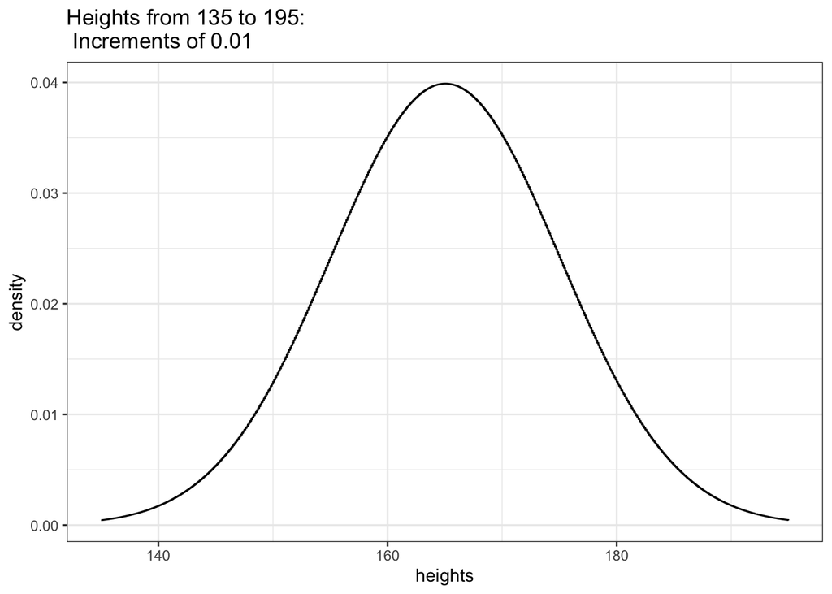

```r
figure_10<-ggplot()+
  geom_step(data=dnorm_df2, mapping=aes(y=density, x=heights)) +
  theme_bw()+
  ggtitle("Heights from 135 to 195:\n Increments of 0.01")
figure_10
```

Let us see how changing some of these parameters may affect the appearance of our bell curve

## 6.1 Sequence of Heights from 135 to 195: Increments of 1

```r
list_heights<-seq(135, 195, by =1)
dnorm_df_3<-dnorm(list_heights, mean = 165, sd = 10)
dnorm_df_3<-data.frame(dnorm_df_3)
names(dnorm_df_3)<-"density"
dnorm_df_3<-cbind(dnorm_df_3, list_heights)
names(dnorm_df_3)[names(dnorm_df_3)=="list_heights"]<-"heights"
```

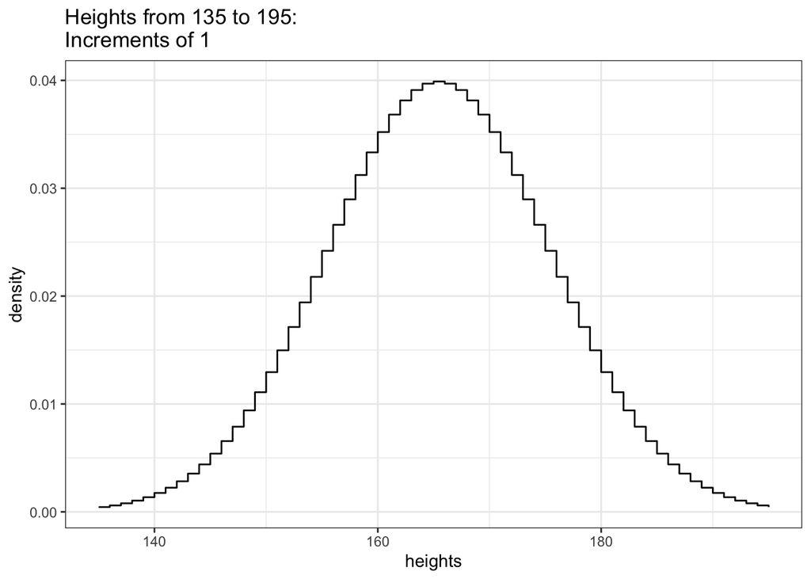

```r
figure_11<-ggplot()+
  geom_step(data=dnorm_df_3, mapping=aes(y=density, x=heights)) +
  theme_bw()+
  ggtitle("Heights from 135 to 195:\nIncrements of 1")
figure_11
```

## 6.2 Sequence of Heights from 135 to 195: Increments of 10

```r
list_heights<-seq(135, 195, by =10)
dnorm_df_4<-dnorm(list_heights, mean = 165, sd = 10)
dnorm_df_4<-data.frame(dnorm_df_4)
names(dnorm_df_4)<-"density"
dnorm_df_4<-cbind(dnorm_df_4, list_heights)
names(dnorm_df_4)[names(dnorm_df_4)=="list_heights"]<-"heights"
```

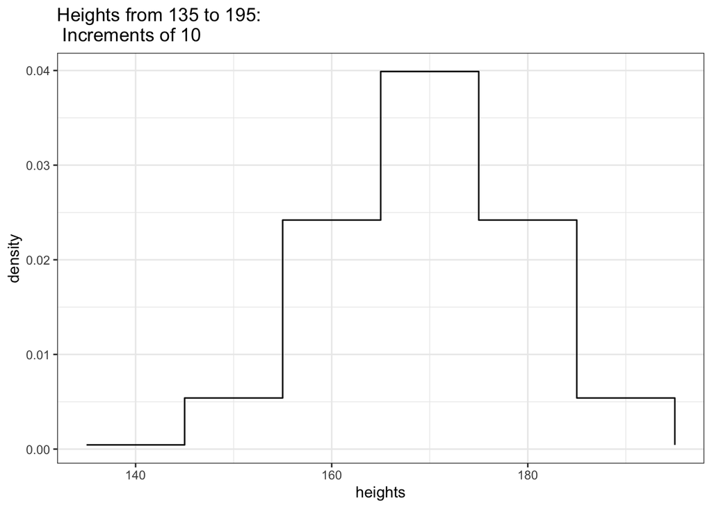

```r
figure_12<-ggplot()+
  geom_step(data=dnorm_df_4, mapping=aes(y=density, x=heights)) +
  geom_bar(stat="identity")+
  theme_bw()+
  ggtitle("Heights from 135 to 195:\n Increments of 10")
figure_12
```

Comparing them

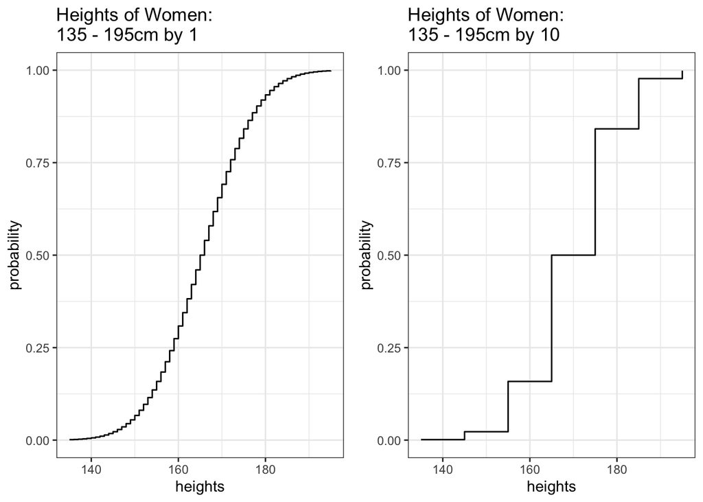

```r
grid.arrange(figure_8, figure_9, ncol=2)
```

Here too, smaller increments generate more data points for the CDF. This creates a smoother, more continuous-looking CDF. With by = 10, the CDF is “jumpy” because there are fewer points.

Let’s do some problems now.

# 7 Normal vs. Non-Normal Distributions

As you might suspect, life expectancy in our dataset is not normally distributed.

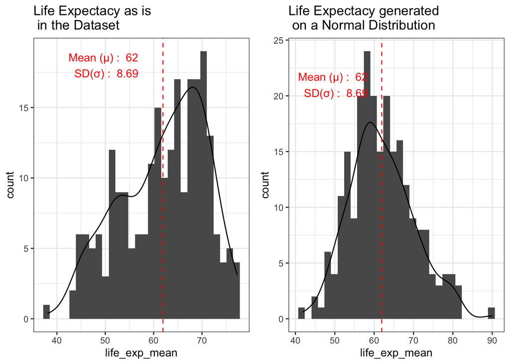

```r
#Setting path
setwd("/Users/bgpopescu/Dropbox/john_cabot/teaching/stats/week5/lab/data/")
#Step1: Loading the data
life_expectancy_df <- read.csv(file = './life-expectancy.csv')
library(dplyr)

#Step2: Calculating the mean
life_expectancy_df2<-life_expectancy_df%>%
  dplyr::group_by(Code)%>%
  dplyr::summarize(life_exp_mean=mean(Life.expectancy.at.birth..historical.))

#Step3: Getting rid of countries
weird_labels <- c("OWID_KOS", "OWID_WRL", "")
clean_life_expectancy_df<-subset(life_expectancy_df2, !(Code %in% weird_labels))

#Step4: Calculating the mean and SDin the dataset
mean_empirical<-mean(clean_life_expectancy_df$life_exp_mean, na.rm = T)
mean_empirical_val<-as.character(round(mean_empirical, 0))
sd_empirical<-sd(clean_life_expectancy_df$life_exp_mean, na.rm = T)
sd_empirical_val<-as.character(round(sd(clean_life_expectancy_df$life_exp_mean, na.rm = T), 2))

#Step5: Creating annotation text
lines<- paste("Mean (\u03BC)", ": ", mean_empirical_val, "\n", "SD(\u03C3)", ": ", sd_empirical_val)

#Step6: Making the histogram for the dataset
y_coord<-18
fig_hist1<-ggplot(data = clean_life_expectancy_df, aes(x=life_exp_mean))+
  geom_histogram()+
  #Multiplying by 1.5. Otherwise, density will not be visible
  geom_density(aes(y=..count..*1.5))+
  theme_bw()+
  geom_vline(xintercept=mean_empirical, linetype='dashed', col = 'red')+
  ggtitle("Life Expectacy as is\n in the Dataset")+
  annotate(geom="text",
           x=mean_empirical-12,
           y=y_coord,
           label=lines,
           color="red")+
  ylab("count")

#Step7: Generating 235 observations following a normal distribution with same mean and standard deviation
set.seed(123)
generated_data<-rnorm(235, mean=mean_empirical, sd=sd_empirical)
generated_data<-data.frame(generated_data)
names(generated_data)<-"life_exp_mean"

#Step8: Making the histogram for the generated dataset
fig_hist2<-ggplot(data = generated_data, aes(x=life_exp_mean))+
  geom_histogram()+
  #Multiplying by 1.5. Otherwise, density will not be visible
  geom_density(aes(y=..count..*1.5))+
  theme_bw()+
  geom_vline(xintercept=mean_empirical, linetype='dashed', col = 'red')+
  ggtitle("Life Expectacy generated\n on a Normal Distribution")+
  annotate(geom="text",
           x=mean_empirical-12,
           y=y_coord+3,
           label=lines,
           color="red")+
  ylab("count")

#Step9: Comparing the two histograms
grid.arrange(fig_hist1, fig_hist2, ncol=2)
```

How do we do we obtain these graphs? Let us work on the first graph.

## 7.1 Working with the empirical (actual) data

Let us go back to the life expectancy dataset

Copy and paste the life expectancy dataset from Lab 4 or download it again. You can download the life expectancy dataset below:

- [Life expectancy data](https://www.dropbox.com/s/wdcv05v7sjkiomn/life-expectancy.csv?dl=0)

## 7.2 Load the dataset

```r
#Setting path
setwd("/Users/bgpopescu/Dropbox/john_cabot/teaching/stats/week5/lab/data/")
life_exp_mean <- read.csv(file = './life-expectancy.csv')
```

## 7.3 Calculating the mean

```r
life_exp_mean2<-life_exp_mean%>%
  dplyr::group_by(Code, Entity)%>%
  dplyr::summarize(life_exp_mean=mean(Life.expectancy.at.birth..historical.))
```

## 7.4 Clearning the Data

```r
weird_labels <- c("OWID_KOS", "OWID_WRL", "")
clean_life_exp_mean_df<-subset(life_exp_mean2, !(Code %in% weird_labels))
```

## 7.5 Calculating the mean and SD in the dataset

```r
mean_empirical<-mean(clean_life_exp_mean_df$life_exp_mean, na.rm = T)
mean_empirical_val<-as.character(round(mean_empirical, 0))
sd_empirical<-sd(clean_life_exp_mean_df$life_exp_mean, na.rm = T)
sd_empirical_val<-as.character(round(sd(clean_life_exp_mean_df$life_exp_mean, na.rm = T), 2))
```

## 7.6 Creating annotation text

```r
lines<- paste("Mean (\u03BC)", ": ", mean_empirical_val, "\n", "SD(\u03C3)", ": ", sd_empirical_val)
```

## 7.7 Making the histogram for the dataset

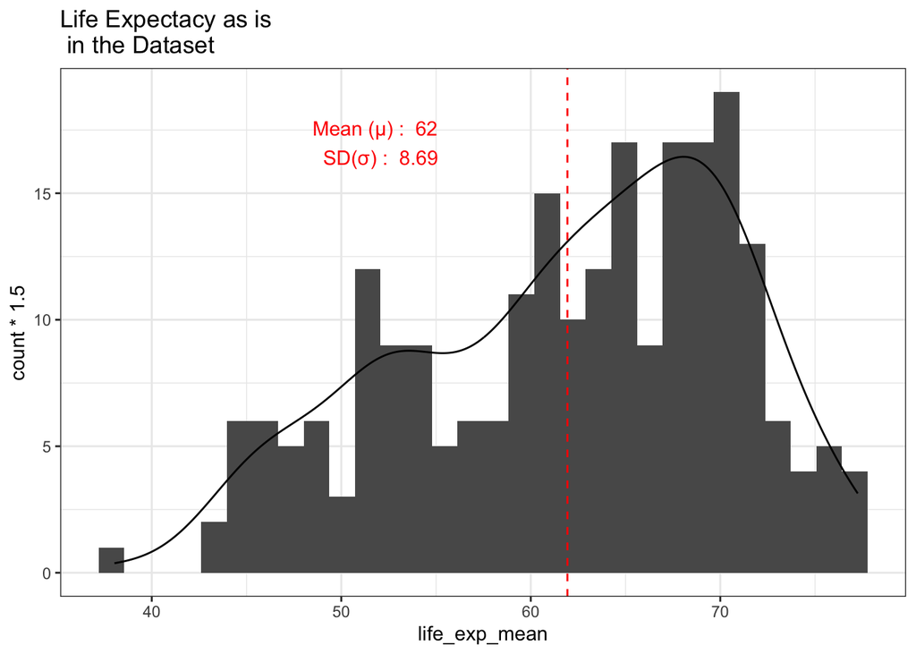

```r
y_coord<-17
fig_hist1<-ggplot(data = clean_life_exp_mean_df, aes(x=life_exp_mean))+
  geom_histogram()+
  #Multiplying by 1.5. Otherwise, density will not be visible
  geom_density(aes(y=..count..*1.5))+
  theme_bw()+
  geom_vline(xintercept=mean_empirical, linetype='dashed', col = 'red')+
  ggtitle("Life Expectacy as is\n in the Dataset")+
  annotate(geom="text",
           x=mean_empirical-10,
           y=y_coord,
           label=lines,
           color="red")
fig_hist1
```

# 8 Working with the made-up (generated) data

## 8.1 Generating 235 observations following a normal distribution with same mean and standard deviation

```r
#Step7: Generating 235 observations following a normal distribution with same mean and standard deviation
set.seed(123)
generated_data<-rnorm(235, mean=mean_empirical, sd=sd_empirical)
generated_data<-data.frame(generated_data)
names(generated_data)<-"life_exp_mean"
```

## 8.2 Making the histogram for the generated dataset

```r
fig_hist2<-ggplot(data = generated_data, aes(x=life_exp_mean))+
  geom_histogram()+
  #Multiplying by 1.5. Otherwise, density will not be visible
  geom_density(aes(y=..count..*1.5))+
  theme_bw()+
  geom_vline(xintercept=mean_empirical, linetype='dashed', col = 'red')+
  ggtitle("Life Expectacy generated\n on a Normal Distribution")+
  annotate(geom="text",
           x=mean_empirical-12,
           y=y_coord+6,
           label=lines,
           color="red")+
  ylab("count")
```

# 9 Comparing the two histograms

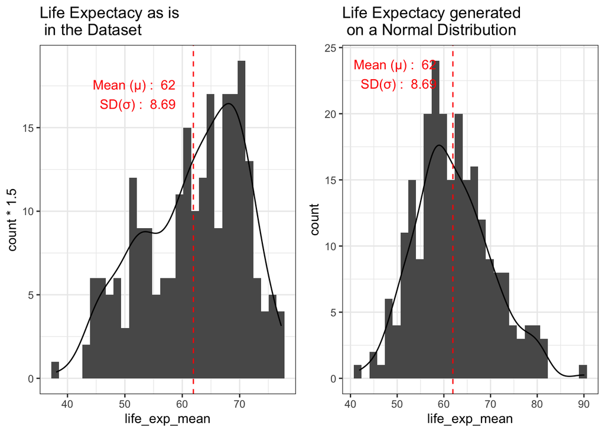

```r
grid.arrange(fig_hist1, fig_hist2, ncol=2)
```

## 9.1 Generating more observations following a normal distribution with same mean and standard deviation

```r
generated_data_1000obs<-rnorm(1000, mean=mean_empirical, sd=sd_empirical)
generated_data_1000obs<-data.frame(generated_data_1000obs)
names(generated_data_1000obs)<-"life_exp_mean"
```

## 9.2 Making the histogram for the generated dataset (1000 obs.)

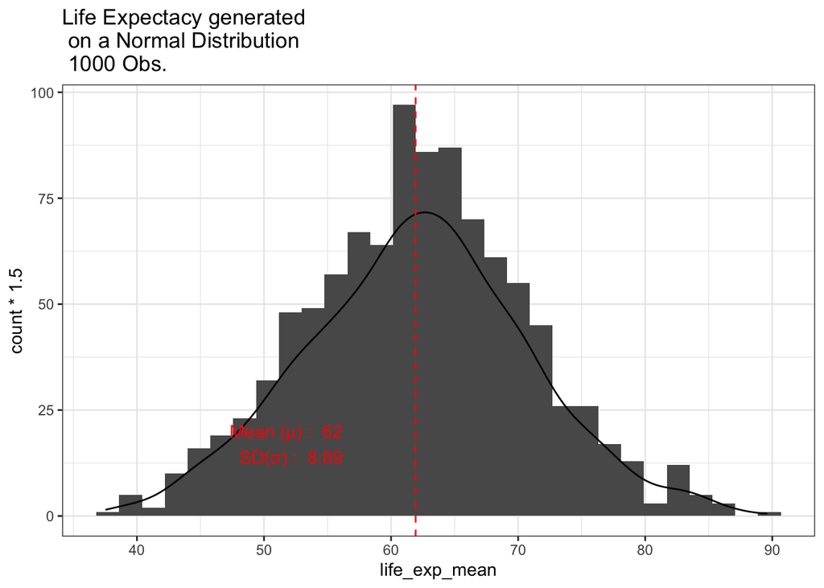

```r
fig_hist3<-ggplot(data = generated_data_1000obs, aes(x=life_exp_mean))+
  geom_histogram()+
  #Multiplying by 1.5. Otherwise, density will not be visible
  geom_density(aes(y=..count..*1.5))+
  theme_bw()+
  geom_vline(xintercept=mean_empirical, linetype='dashed', col = 'red')+
  ggtitle("Life Expectacy generated\n on a Normal Distribution\n 1000 Obs.")+
  annotate(geom="text",
           x=mean_empirical-10,
           y=y_coord,
           label=lines,
           color="red")
fig_hist3
```

So, we can see that by having more observations, our dataset approaches something that looks like a normal distribution. Note that our mean $\mu$ and standard deviation $\sigma$ are the same as in the original data.

# 10 Problem

Let’s assume that the data in our original empirical dataset is normally distributed with the mean of 61.93 years and a standard deviation of 8.69 years.

## 10.1 Life expectancy of less than or equal 50 years

What is the probability that a randomly selected country will have a life expectancy of less than or equal 50 years?

```r
ctry_50<-subset(life_exp_mean2, life_exp_mean<=50)
ctry_50
```

| Code | Entity | life_exp_mean |
| --- | --- | --- |
|  | Africa | 49.66438 |
|  | Least developed countries | 49.81250 |
|  | Low-income countries | 48.51389 |
| AFG | Afghanistan | 45.38333 |
| AGO | Angola | 45.08466 |
| BDI | Burundi | 47.43056 |
| BEN | Benin | 49.25694 |
| BFA | Burkina Faso | 46.54583 |
| CAF | Central African Republic | 46.33750 |
| CIV | Cote d'Ivoire | 48.49167 |

[output cut: 20 more lines]

```r
nrow(ctry_50)/nrow(life_exp_mean2)
```

```
[1] 0.1171875
```

The probability that a randomly selected country will have a life expectancy of less than or equal to 50 years is 0.12.

Let us also visualize this probability. We will proceed by calculating the frequency table.

```r
#Step1: Rounding the heights
new_data2<-life_exp_mean2
new_data2$life_exp_mean_rounded<-round(new_data2$life_exp_mean, 0)
head(new_data2, n=5)
```

| Code | Entity | life_exp_mean | life_exp_mean_rounded |
| --- | --- | --- | --- |
|  | Africa | 49.66438 | 50 |
|  | Americas | 66.77273 | 67 |
|  | Asia | 59.20933 | 59 |
|  | Europe | 68.98101 | 69 |
|  | High-income countries | 73.85139 | 74 |

```r
#Step2: Creating a frequency table
freq_table<-table(new_data2$life_exp_mean_rounded)
freq_table
```

```
38 43 44 45 46 47 48 49 50 51 52 53 54 55 56 57 58 59 60 61 62 63 64 65 66 67
 1  2  3  4  4  5  5  3  4  5 12  6  5  6  5  6  7  8 11 10  7  8 14 13  5 15
68 69 70 71 72 73 74 75 77
10 15 14 14  8  6  3  8  4
```

```r
#Step3: Turning the table into a dataframe
freq_table<-data.frame(freq_table)
```

```r
#Step4: Providing more intuitive names
names(freq_table)[1]<-"life_exp_mean_rounded"
names(freq_table)[2]<-"count"
names(freq_table)
```

```
[1] "life_exp_mean_rounded" "count"
```

```r
#Step5: Turning factor variables into numeric
freq_table$life_exp_mean_rounded<-as.numeric(as.character(freq_table$life_exp_mean_rounded))
str(freq_table)
```

```
'data.frame':   35 obs. of  2 variables:
 $ life_exp_mean_rounded: num  38 43 44 45 46 47 48 49 50 51 ...
 $ count                : int  1 2 3 4 4 5 5 3 4 5 ...
```

```r
#Step6: Calculaing the PMFs
freq_table$sum_frequency<-sum(freq_table$count)
freq_table$pmf<-freq_table$count/freq_table$sum_frequency
head(freq_table, n=5)
```

|  | life_exp_mean_rounded | count | sum_frequency | pmf |
| --- | --- | --- | --- | --- |
| 1 | 38 | 1 | 256 | 0.00390625 |
| 2 | 43 | 2 | 256 | 0.00781250 |
| 3 | 44 | 3 | 256 | 0.01171875 |
| 4 | 45 | 4 | 256 | 0.01562500 |
| 5 | 46 | 4 | 256 | 0.01562500 |

The next step is to create the CDF. A CDF tells us probability that the randomly generated variable X takes on a height less than or equal to x. We will be using the function that we created previously.

```r
#Step7: Calculating the CDF
new_data2$cdf <- ecdf(new_data2$life_exp_mean_rounded)(new_data2$life_exp_mean_rounded)
```

Plotting the CDF

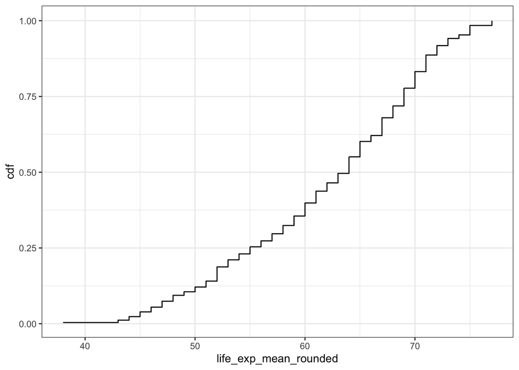

```r
#Step8: Plotting the CDF
figure_13<-ggplot()+
  geom_step(data=new_data2, mapping=aes(x=life_exp_mean_rounded, y=cdf)) +
  geom_bar(stat="identity")+
  theme_bw()
figure_13
```

Merging the PMFs to the dataset

```r
#Step9: Selecting only the relevant variables
freq_table_x<-subset(freq_table, select = c(life_exp_mean_rounded, pmf))
head(freq_table_x, n=10)
```

|  | life_exp_mean_rounded | pmf |
| --- | --- | --- |
| 1 | 38 | 0.00390625 |
| 2 | 43 | 0.00781250 |
| 3 | 44 | 0.01171875 |
| 4 | 45 | 0.01562500 |
| 5 | 46 | 0.01562500 |
| 6 | 47 | 0.01953125 |
| 7 | 48 | 0.01953125 |
| 8 | 49 | 0.01171875 |
| 9 | 50 | 0.01562500 |
| 10 | 51 | 0.01953125 |

```r
#Step10: Performing the left join
new_data3<-left_join(new_data2, freq_table_x, by=c("life_exp_mean_rounded" = "life_exp_mean_rounded"))
```

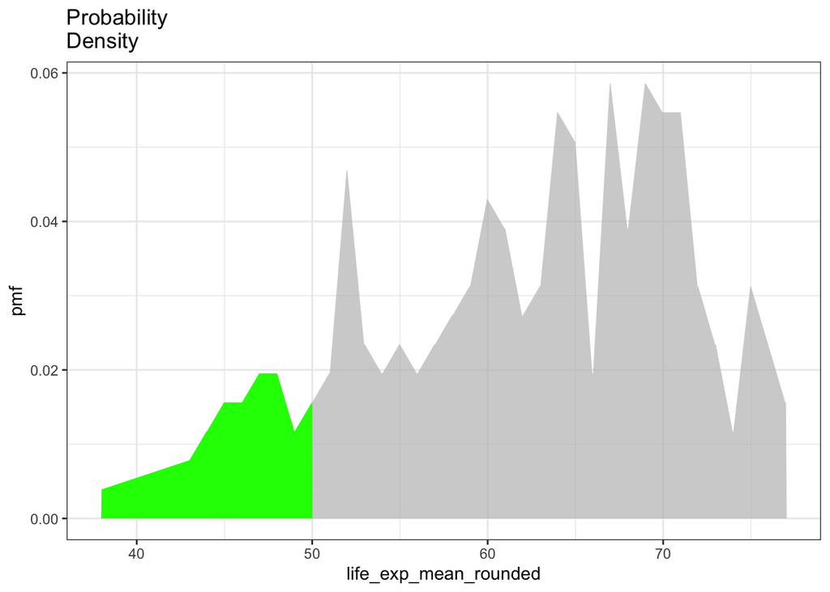

```r
#Probability Density
figure_14<-ggplot(data=new_data3, mapping=aes(x=life_exp_mean_rounded, y=pmf)) +
  geom_area(fill = "green") +
  gghighlight(new_data2$life_exp_mean_rounded <= 50)+
  theme_bw()+
  ggtitle("Probability\nDensity")
figure_14
```

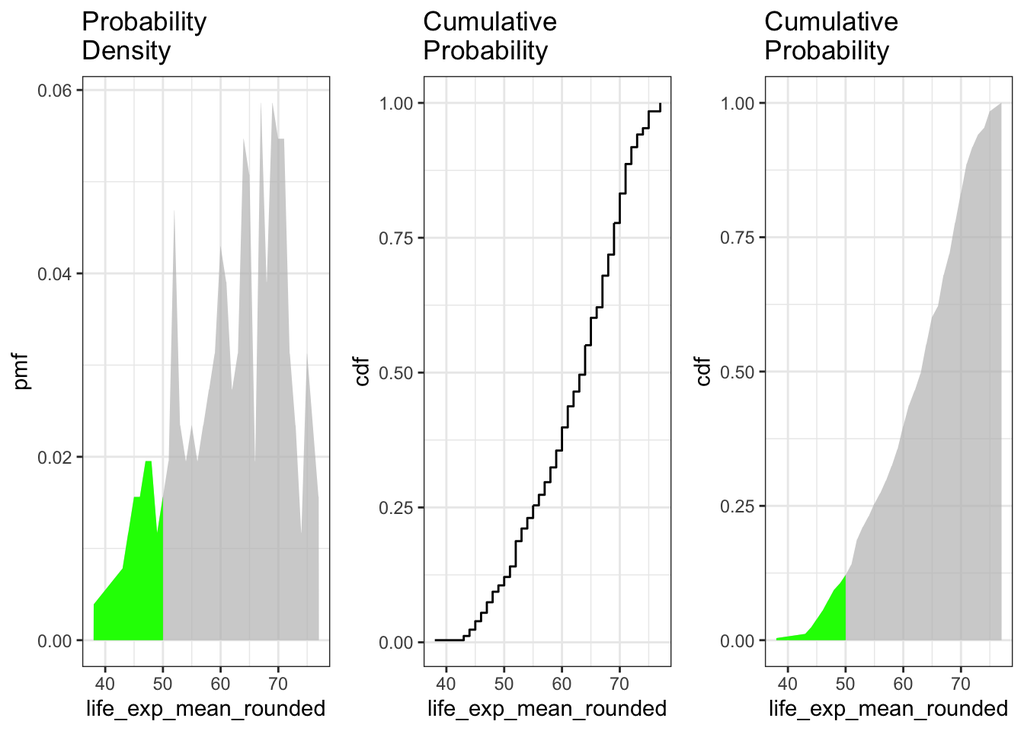

```r
#Cumulative Probability
figure_15<-ggplot()+
  geom_step(data=new_data2, mapping=aes(x=life_exp_mean_rounded, y=cdf)) +
  geom_area(fill = "green") +
  geom_bar(stat="identity")+
  theme_bw()+
  ggtitle("Cumulative\nProbability")

#Cumulative Probability < 50
figure_16<-ggplot(data=new_data2, aes(x=life_exp_mean_rounded, y=cdf)) +
  geom_area(fill = "green") +
  gghighlight(new_data2$life_exp_mean_rounded <= 50)+
  theme_bw()+
  ggtitle("Cumulative\nProbability")


grid.arrange(figure_14, figure_15, figure_16, ncol=3)
```

If our distribution was normal, it would look different:

It would look something like the following:

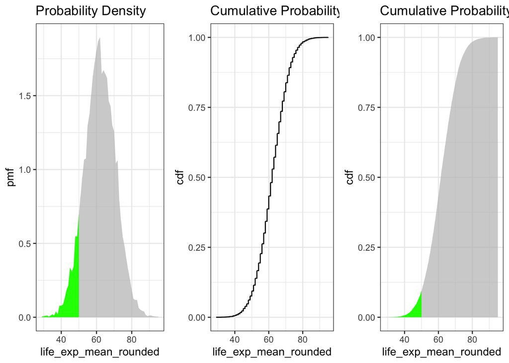

If we assume a normal distribution, we can simply get this answer this way:

```r
res<-pnorm(50, mean = mean_empirical, sd = sd_empirical)
res
```

```
[1] 0.08475828
```

## 10.2 Life expectancy of more than 70 years

What is the probability that a randomly selected country will have a life expectancy of more than 70 years?

So remember that the CDF is the probability that the randomly generated variable X takes on a height LESS than or equal to x. We will first subset the data to less than 70 and take the complement.

```r
prob_more_70<-subset(new_data2, life_exp_mean_rounded<70)
1-max(prob_more_70$cdf)
```

```
[1] 0.2226562
```

Therefore, probability of getting a country with a life expectancy of greater than 70 is 0.22.

If we assume a normal distribution, we can simply get a similar answer this way:

```r
res<-pnorm(70, mean = mean_empirical, sd = sd_empirical)
1-res
```

```
[1] 0.1765817
```

Here is what it looks like

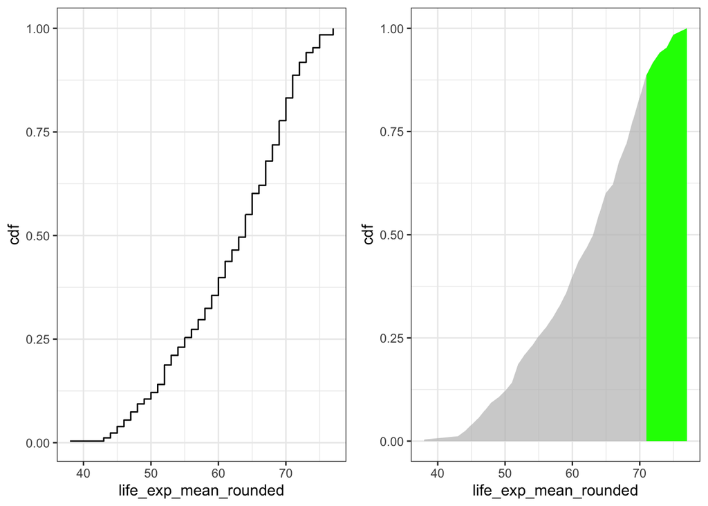

```r
figure_20<-ggplot()+
  geom_step(data=new_data2, mapping=aes(x=life_exp_mean_rounded, y=cdf)) +
  geom_area(fill = "green") +
  geom_bar(stat="identity")+
  theme_bw()


figure_21<-ggplot(data=new_data2, aes(x=life_exp_mean_rounded, y=cdf)) +
  geom_area(fill = "green") +
  gghighlight(new_data2$life_exp_mean_rounded > 70)+
  theme_bw()

grid.arrange(figure_20, figure_21, ncol=2)
```

## 10.3 Percentile

What is the 90th percentile of life expectancy?

We can obtain this by - ordering the ages and calculate the percentile - subset based on CDF and get the minimum

```r
list_ages<-new_data2$life_exp_mean_rounded
list_ages<-list_ages[order(list_ages)]
quantile(new_data2$life_exp_mean_rounded, c(0.90))
```

```
90%
 72
```

```r
pct_90<-subset(new_data2, cdf>0.9)
#pct_90
min(pct_90$life_exp_mean_rounded)
```

```
[1] 72
```

The 90th percentile of life expectancy is 72.

If we assume a normal distribution, we can also use `qnorm`. This generates a vector for the inverse cumulative distribution function of the normal distribution with a mean $\mu$ and a standard deviation $\sigma$. It is not exactly the same, but it is close.

```r
res<-qnorm(0.9, mean = mean_empirical, sd = sd_empirical)
res
```

```
[1] 73.06729
```